# Comprehensive comparison of cloud-based NGS data analysis and alignment tools - ScienceDirect

## Cited By (4)

## Figures (2)

[figure not shown]

## Tables (5)

[figure not shown]

## [Informatics in Medicine Unlocked](https://www.sciencedirect.com/journal/informatics-in-medicine-unlocked)

[Volume 18](https://www.sciencedirect.com/journal/informatics-in-medicine-unlocked/vol/18/suppl/C), 2020, 100296

# Comprehensive comparison of cloud-based NGS data analysis and alignment tools

[QanitaBani Baker<sup>a</sup>](https://www.sciencedirect.com/science/article/pii/S2352914819303673?via%3Dihub#!)[MahmoudHammad<sup>a</sup>](https://www.sciencedirect.com/science/article/pii/S2352914819303673?via%3Dihub#!)[WesamAl-Rashdan<sup>a</sup>](https://www.sciencedirect.com/science/article/pii/S2352914819303673?via%3Dihub#!)[YaserJararweh<sup>a</sup><sup>b</sup>](https://www.sciencedirect.com/science/article/pii/S2352914819303673?via%3Dihub#!)[MohammadAL-Smadi<sup>a</sup>](https://www.sciencedirect.com/science/article/pii/S2352914819303673?via%3Dihub#!)[MohammadAl-Zinati<sup>a</sup>](https://www.sciencedirect.com/science/article/pii/S2352914819303673?via%3Dihub#!)

https://doi.org/10.1016/j.imu.2020.100296[Get rights and content](https://s100.copyright.com/AppDispatchServlet?publisherName=ELS&contentID=S2352914819303673&orderBeanReset=true)

Under a Creative Commons [license](https://creativecommons.org/licenses/by-nc-nd/4.0/)

Open access

## Abstract

Next-Generation Sequencing (NGS) is very helpful for conducting DeoxyriboNucleic Acid (DNA) Sequencing. DNA sequencing is the process for determining the order (sequence) of the main chemical bases in the DNA. Analyzing human DNA sequencing is important for determining the possibility that a person will develop certain diseases, and/or the ability to respond to medication. However, the NGS process is a complicated and resource-hungry technical process. To solve this dilemma, the majority of NGS software systems are deployed as cloud-based services distributed over cloud-based platforms. Cloud-based platforms provide promising solutions for the computationally intensive tasks required by the NGS data analysis. This work provides a comprehensive investigation of cloud-based NGS data analysis and alignment tools, both the commercial and the open-source tools. We also discuss in detail the main features and setup requirements for each tool, and then compare and contrast between them. Moreover, we extensively analyze and classify the studied NGS data analysis and alignment tools to help NGS biomedical researchers and clinicians in finding appropriate tools for their work, while understanding the similarities and the differences between them.

## Keywords

Next-generation sequencing (NGS)

Sequence alignment

Cloud computing

Big data

Bioinformatics

## 1. Introduction

DeoxyriboNucleic Acid (DNA) is a [nucleic acid](https://www.sciencedirect.com/topics/medicine-and-dentistry/nucleic-acid) that contains all of the genetic instruction for an organism. Each molecule of DNA contains a chemical base which could be one of four types: adenine (A), cytosine (C), thymine (T), and guanine (G). These chemical bases or letters are the main [building blocks](https://www.sciencedirect.com/topics/computer-science/building-blocks) of the DNA. A person has about 3 billion pairs of these letters, with the exact order or sequence being called genomic sequence. DNA sequencing is the process that enables scientists to read the exact order or sequence of all letters that make up the complete set of DNA, the genome. Thereafter, the [DNA sequence](https://www.sciencedirect.com/topics/medicine-and-dentistry/dna-sequence) is compared to a standardized code to identify the variance between the two sets of letters.

There are many benefits of DNA sequencing including determining the possibility of a person for developing certain diseases such as cancer, heart disease, or type II diabetes. It also can determine the ability of a person to respond to certain medications, a technique known as *pharmacogenomics*. Moreover, some genomic disorders provide an indication that a person may develop rare cases of disease such as [Huntington disease](https://www.sciencedirect.com/topics/medicine-and-dentistry/huntingtons-disease) (a progressive brain disorder). The Next-Generation Sequencing (NGS) is defined as a massively parallelized sequencing technology that produces high-throughput DNA reading sequencing at a comparatively minimal cost [1]. NGS is considered a cutting-edge technologies in biological and [biomedical research](https://www.sciencedirect.com/topics/medicine-and-dentistry/biomedical-research) [2,3].

NGS differs from [Sanger sequencing](https://www.sciencedirect.com/topics/medicine-and-dentistry/sanger-sequencing), which is also called first-generation sequencing [4], in sequencing volume, in cost, in the velocity of sequencing, and in the amount of DNA data produced [5]. Compared with the third-generation sequencing techniques, NGS also differs [6] in many characteristics as discussed in Refs. [[7], [8], [9], [10]]. As presented in Ref. [11], Single-Molecule Sequencing (SMS), simple divergence from previous technologies, enabling a single molecule sequencing, and real-time sequencing are all characterizing as third-generation sequencing platforms. NGS technologies are evolved in clinical tests [12] and in revolutionary innovations to genomic studies [13]. Recently, NGS technologies have become routine procedures in Biotechnology research. DNA sequencing data analysis is a core procedure of the diagnostic test [14]. NGS provides considerable low-cost alternatives for several applications [15].

Advances in NGS technologies have resulted in an unprecedented proliferation of genomic sequence data. Therefore, several NGS data-related challenges are presented, especially in analytics and storage [16]. Therefore, to enhance the performance of the NGS tasks, the majority of NGS software systems are deployed as cloud-based services distributed over cloud-based platforms. Cloud computing is an emerging technology that provides a different infrastructure for tackling computational challenges in NGS data analysis [[17], [18], [19]]. Generally, the [cloud computing service](https://www.sciencedirect.com/topics/computer-science/cloud-computing-service) models are classified into three types: Platform as a Service (PaaS), Software as a Service (SaaS), and Infrastructure as a Service (IaaS) [20,21]. In addition to these models, the [bioinformatic](https://www.sciencedirect.com/topics/computer-science/bioinformatics) cloud services that are mentioned in Refs. [4,22,23], and [24] added another model to the three models, called Data as a Service known (DaaS). Moreover, many studies also divide the types of the cloud into three main categories (private, public, and hybrid) [25]. In this paper, we extended our preliminary work in Ref. [26] and we have studied 47 cloud-based tools that are widely used in NGS data analysis, instead of only 20 NGS tools that have been studied elsewhere [26]. In addition, we also included 13 open-source and cloud-based NGS alignment tools that are widely used in the NGS data analysis. Moreover, in this paper, we described the functionality, features, and setup requirements for each NGS and alignment tool. We present a comparison between these tools in order to assist clinicians and researchers to choose the appropriate tools according to their working environments. To the best of our knowledge, this study is the first comprehensive study that investigates the widely used commercial and open-source cloud-based NGS and alignment tools.

The remainder of the paper includes the following sections: in Section 2, we discuss research efforts related to our work. Then, in Section 3, we present our methodology for conducting this study. In Section 4, we discuss the open, commercial, and alignment tools operating on various cloud services. Finally, in Section 6, we conclude the paper and suggest future directions.

## 2. Related work

In this section, we present some of the previous works that have focused on studying [NGS](https://www.sciencedirect.com/topics/medicine-and-dentistry/next-generation-sequencing) platforms and tools. We show the works that have investigated NGS platforms. Then, we highlight studies that have introduced the NGS data as a [big data](https://www.sciencedirect.com/topics/computer-science/big-data) domain, and we refer to the studies that utilized cloud computing technology in NGS. At the end of this section, we introduce other studies that provide overviews of NGS tools in the cloud, and we discuss the shortcomings in these studies that motivated us in this work.

Recently, many Next-generation Sequencing platforms have emerged [3,13] such as ABI SOLiD, Illumina GA, and Roche 454. However, there are great needs for more NGS tools, as stated in Ref. [5]. Till now, NGS technologies have been successfully applied to several applications, such as RNA-sequencing [27], ChIP-sequencing [28], whole human [genome sequencing](https://www.sciencedirect.com/topics/medicine-and-dentistry/genome-sequencing) [29], and genome-wide structural variation [30]. Many studies have evaluated and investigated NGS platforms in several applications [13,[31], [32], [33], [34]]. For example, in Ref. [32], Loman et al. evaluated the performance of three different NGS platforms which are MiSeq (from Illumina), 454 GS Junior (from Roche), and Ion Torrent [PGM](https://www.sciencedirect.com/topics/medicine-and-dentistry/phosphoglucomutase) (from Life Technologies). They compared these platforms using several criteria including quality, the performance of the platforms, read length, read error rate, and completeness. Based on many previous studies, Illumina platforms are the most used and well-known platforms in the market [[35], [36], [37]].

The big-data generated from NGS technologies causes challenges with storing, analyzing, and managing this data [17]. Elazhary [20] presented the opportunities and challenges of using cloud computing in processing Big Data. Elazhary [20] also presented computational biology applications as targeted fields. The size and complexity of NGS data have grown rapidly, and the extension of computing capabilities is becoming essential [17]. Cloud computing is considered as a replacement of the current on-premises solutions to address several issues in NGS data, as shown in Refs. [17,23]. The importance of cloud computing to handle NGS data analysis is discussed in many works [4,16,38]. Dai et al. [22] reviewed cloud-based services in the bioinformatics domain, and they classified them into DaaS, PaaS, SaaS, and IaaS. Then they presented their perspectives on utilizing cloud computing in the bioinformatics arena. In their review, they did not focus on the NGS, and they reviewed some of the cloud-based resources in bioinformatics.

Several efforts were taken to study and provide overviews of NGS analysis tools. In Ref. [16], Celesti et al. provided a taxonomy of the NGS cloud-based tools according to cloud service levels. They presented a taxonomic tree of cloud-based systems by showing NGS applications. Thakur et al. [18] also presented cloud-based computing in biological systems, focusing on genomic informatics, comparative genomics, metagenomics, and SNP detection. Moreover, Zhao et al. [23] reviewed a part of cloud-based tools and systems used for NGS data analysis. They discussed the practical limitations and hurdles that can be found in cloud computing, focusing on security and data transfer. They also showed bioinformatics platforms and cloud-based services along with some applications. They classified these platforms into commercial systems, commercial or open bioinformatics platforms, and open-source tools. Geo et al. [4] presented an overview of Cloud Computing and they showed how cloud-computing services provide support for NGS data analysis. They provided a summary of some cloud-based resources used for NGS data analysis. In addition to these works, Kwon et al. also used two types to classify the tools for NGS i.e., commercial services and open-source tools [17].

None in previous works have addressed features and setup requirements for the NGS cloud-based tools. From investigating the previous works, we find it is essential to develop a study that addresses cloud-based tools for NGS analysis. Our study provides a comparison between the tools which help clinicians, scientists, and researchers to choose the proper tool according to working environments. To the best of our knowledge, this study is the first comprehensive study that investigates the commercial and open-source cloud-based NGS and alignment tools, and provides up-to-date investigation of them. Sixty NGS tools are reported in this study, divided as 41 open-source NGS tools, 6 commercial NGS tools, and 13 NGS alignment tools.

## 3. Methodology

In this section, we describe our methodology for collecting [NGS](https://www.sciencedirect.com/topics/medicine-and-dentistry/next-generation-sequencing) data analysis tools and NGS alignment tools. We focus only on cloud-based NGS tools, due to their capability for handling [big data](https://www.sciencedirect.com/topics/computer-science/big-data) generated from NGS technologies. We also focus on NGS alignment tools that also can be deployed on cloud services. Then, we describe the main features that biomedical researchers and clinicians consider for selecting NGS and alignment tools. Although these tools are cloud-based, most of them offer a desktop version for users to download and utilize.

### 3.1. Selected NGS tools

We include widely used cloud-based NGS tools collected from previous studies [4,16,17], and [23]. The NGS tools that we have excluded are either non-cloud-based NGS tools such as the BioPerl tool [39] or cloud-based NGS tools but not active or supported anymore such as the Roundup tool [40] and CloudTSS tool [41]. As a result of these inclusion/exclusion criteria, we obtained 60 cloud-based NGS data analysis and alignment tools, divided into three categories as follows: 41 open-source NGS tools, 6 commercial NGS tools, and 13 NGS alignment tools.

### 3.2. Descriptive features

To describe and compare between the included NGS tools, we have selected a set of features that are crucial for identifying cloud-based NGS data analysis tools. These features are also important for biomedical researchers and clinicians to select NGS tools. For each category of NGS tool, recall that in Section 3.1, we have identified a set of features related to that category, as shown in Fig. 1. We extracted these features in several ways, including studying the research paper for each tool, exploring the tools' websites, studying tools’ manuals, and utilizing the OMICtools [118]. OMICtools is a website that contains a manually curated metadatabase of [omic](https://www.sciencedirect.com/topics/medicine-and-dentistry/tamsulosin) tools.

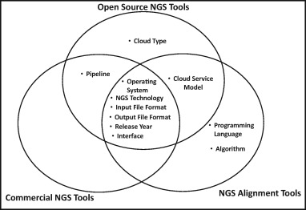

Fig. 1. The descriptive features for all cloud-based [NGS](https://www.sciencedirect.com/topics/medicine-and-dentistry/next-generation-sequencing) and alignment tools.

#### 3.2.1. Features for open-source NGS tools

For this category, we have selected nine important features. Next, we describe these features in more detail:

**1.**

Operating System: describes the operating system the desktop version of the open-source NGS tool requires to operate.

**2.**

NGS technology: displays the NGS technology platform(s) or the hardware equipment the NGS tool is compatible with.

**3.**

[Cloud Service Model](https://www.sciencedirect.com/topics/computer-science/cloud-service-model) (CSM): shows the model of the cloud service for the NGS tool.

**4.**

Cloud Type: displays the type of cloud service for the NGS tool (private, public, or hybrid).

**5.**

Input [File Format](https://www.sciencedirect.com/topics/computer-science/data-type): displays the format for the accepted input file to the NGS tool.

**6.**

Output File Format: displays the format for the output file generated by the NGS tool.

**7.**

Release year: shows the released year for the NGS tool.

**8.**

Interface: displays the type of the interface that the user can use to interact with the NGS tool. The possible interfaces for the NGS tools are: [Web User Interface](https://www.sciencedirect.com/topics/computer-science/web-user-interface) (WUI), [Command Line Interface](https://www.sciencedirect.com/topics/computer-science/command-line-interface) (CLI), [Graphical User Interface](https://www.sciencedirect.com/topics/computer-science/graphical-user-interface) (GUI), and [Application Programming Interface](https://www.sciencedirect.com/topics/computer-science/application-programming-interface) (API).

**9.**

Pipeline: this feature shows if the tool uses a pipeline technique or not. The Pipeline is defined as the steps used for analyzing the data when the output from one step is an input to the next step.

#### 3.2.3. Features for NGS alignment tools

For this category, we have identified nine features. These nine features are Operating System, NGS technology, Cloud Service Model (CSM), Input File Format, Output File Format, Release year, Interface, [Programming Language](https://www.sciencedirect.com/topics/computer-science/programming-language) (PL), and Algorithm. The description of the first seven features are as described in the open-source NGS tools, whereas the last two are described as follows:

**1.**

Programming Language (PL): displays the programming language used to develop the NGS alignment tool.

**2.**

Algorithm: displays the NGS alignment algorithm the tool performs to analyze and align the data.

## 4. Results

This section presents the results of our methodology for extracting the features of the commonly used [NGS](https://www.sciencedirect.com/topics/medicine-and-dentistry/next-generation-sequencing) and alignment tools.

In this work, we investigated 41 open-source NGS tools obtained from applying inclusion/exclusion criteria shown in the Methodology section (see Table 1). It is difficult to fit all tools in one table, so we divided the NGS tools into dual five year time spans based on the tool's published year. Table 2 covers the tools published in the years from 2005 to 2012, while Table 3 shows the tools published in the years from 2013 to 2017. Both Table 2, Table 3 depict the nine features, described in Section 3.2.1, of the 41 selected open-source NGS tools. As shown in Table 2, Table 3, all of the desktop versions of the open-source tools work with the Linux/Unix operating system. However, eight of them work with Windows and eight of them work with the MacOS operating system.

Table 1. All of the included [NGS](https://www.sciencedirect.com/topics/medicine-and-dentistry/next-generation-sequencing) tools.

| Open source NGS Tool | Open source NGS Tool | Open source NGS Tool | Commercial NGS Tool | Alignment NGS Tool |
| --- | --- | --- | --- | --- |
| Galaxy [43,44] | CloudBurst [45] | Crossbow [46] | BaseSpace [47] | BWA [48] |
| SeqMapReduce [49] | DIYA [50] | GATK [51,52] | Bina [53] | SAMtools [54] |
| Myrna [55] | Ergatis [56] | CloVR [57,58,58,59] | DNAnexus [60] | MAQ [61,62] |
| Cloudaligner [63] | RAPSearch2 [64] | Jnomics [65,66] | LifeScope [67] | BLAT [68,69] |
| PeakRanger [70] | ArrayExpressHTS [71] | SIMPLEX [72] | GeneSifter [73] | BLAST [[74], [75], [76]] |
| Rainbow [77] | MEGAN [78] | Stormbow [79] | SevenBridges [80] | MUMmer GPU 2.0 [81] |
| BioPig [82] | Eoulsan [83] | Atlas2 [84] |  | MUMmer [[85], [86], [87]] [88] |
| TREAT [89] | Cloud BioLinux [90] | HugeSeq [91] |  | SHRiMP [92,93] |
| VAT [94] | FX [95] | YunBe [96] |  | Bowtie [97] |
| CloudMan [98,99] | Hadoop-BAM [100] | SparkSeq [101] |  | Bowtie2 [102] |
| BioVLAB-MMIA-NGS [103] | Contrail [104] | Mercury [105] |  | SEAL [106] |
| STORMSeq [107] | SURPI [108] | SeqPig [109] |  | TopHat [110] |
| SNP2Structure [111] | Halvade [112] | CLUSTOM-CLOUD [113] |  | HISAT2 [114] |
| MG-RAST [115,116] | MC-GenomeKey [117] |  |  |  |

Table 2. Open-source cloud-based [NGS](https://www.sciencedirect.com/topics/medicine-and-dentistry/next-generation-sequencing) tools developed between years (2005–2012).

| ID | NGS Tool | Operating System | NGS tech-nology | CSM | Cloud Type | Input File | Output File | Release year | Inter-face | Pipe line |
| --- | --- | --- | --- | --- | --- | --- | --- | --- | --- | --- |
| 1 | Galaxy | Windows, Unix, Linux | - | PasS | - | Various * | Various * | 2005 | WI | ✓ |
| 2 | Cloud- Burst | Unix, Linux | Illumina, Solexa | SaaS | Public (Ama- zon EC2) | FASTA | BED | 2009 | CLI |  |
| 3 | Crossbow | Unix, Linux | Illumina | SaaS | Public (Ama- zon EC2) | FASTQ | Stream of SNP calls | 2009 | CLI | ✓ |
| 4 | Seq-Map- Reduce | Unix, Linux | Illumina, Solexa | SaaS | Public (Ama- zon EC2) | - | ELAND | 2009 | WI |  |
| 5 | DIYA | Unix, Linux | Roche/454 Sequencing GS-FLX instruments | IaaS | - | FASTA | Various * | 2009 | CLI | ✓ |
| 6 | GATK | Unix, Linux, MacOS | Illumina/ HiSeq, Biosystems SOLiD System, 454 Life Sciences | SaaS, IaaS | - | BAM, SAM | VCF | 2010, 2011 | CLI | ✓ |
| 7 | Myrna | Unix, Linux | Illumina Genome Analyzer II | SaaS | Public (Ama- zon EC2) | FASTQ | - | 2010 | CLI | ✓ |
| 8 | ERGATIS | Unix, Linux | - | IaaS | - | FASTA, XML | XML | 2010 | CLI, WI | ✓ |
| 9 | CLOVR | Windows, Unix, Linux, MacOS | Roche/454, Illumina | IaaS | Public (Ama- zon EC2), DIAG cloud | SFF, FASTA, QUAL, FASTQ | FASTA, Genbank Flat files | 2011 | CLI, GUI | ✓ |
| 10 | Cloud- Aligner | Unix, Linux | Illumina HiSeq 2000 | SaaS | Public (Ama- zon EC2) | FASTA, FASTQ, SAM | SAM, BED6 | 2011 | CLI |  |
| 11 | RAP-Search2 | Unix, Linux | - | IaaS | Public (Ama- zon EC2) | FASTA | XML, ASN.1 | 2011 | CLI | ✓ |
| 12 | Jnomics | Unix, Linux | Illumina | SaaS | - | BAM, SAM, FASTQ, BED | SAM | 2011 | CLI | ✓ |
| 13 | Peak- Ranger | Windows, Linux, MacOS | - | SaaS | Public (Ama- zon EC2) | Eland, Bowtie, SAM, BAM, BED | WIG | 2011 | CLI |  |
| 14 | Array- Express HTS | Windows, Unix, Linux, MacOS | Illumina, Solexa | SaaS | - | FASTQ | HTML | 2011 | CLI | ✓ |
| 15 | SIMPLEX | Unix, Linux | Illumina, ABI SOLiD | - | Public (Ama- zon EC2) | FASTQ, FASTA | Pdf, BAM, VCF, TSV, PNG, xlsx | 2012 | CLI | ✓ |
| 16 | Eoulsan | Unix, Linux | Illumina | PaaS | Public (Ama- zon EC2) | FASTQ, FASTA | - | 2012 | CLI |  |
| 17 | Atlas2 | Unix, Linux | Roche/454, Illumina, SOLiD | SaaS | Public (Ama- zon EC2, S3), Gen- boree Work-bench | BAM, FASTA | VCF, LFF | 2012 | CLI | ✓ |
| 18 | TREAT | Unix, Linux | - | - | Public (Ama- zon EC2) | FASTQ, BAM | Various * | 2012 | CLI | ✓ |
| 19 | Cloud Bio Linux | Windows, Unix, Linux, MacOS | - | PaaS, IaaS | Public (Ama- zon EC2) | BAM | - | 2012 | CLI | ✓ |
| 20 | HugeSeq | Unix,Linux | Illumina HiSeq | - | - | FASTQ, FASTA | VCF, GFF | 2012 | CLI | ✓ |
| 21 | VAT | Unix, Linux | - | SaaS | Public (Ama- zon EC2) | VCF | VCF | 2012 | CLI | ✓ |
| 22 | FX | Unix, Linux | Illumina Genome Analyzer IIx | SaaS | Public (Ama- zon EC2) | FASTQ | Various * | 2012 | CLI | ✓ |
| 23 | YunBe | Unix, Linux | BGI | SaaS | Public (Ama- zon EC2), BGI | - | - | 2012 | CLI |  |
| 24 | CloudMan | Unix, Linux | - | PaaS | Public Amazon EC2, private (Open- Stack and Open-Nebula) | FASTQ | - | 2012 | CLI , WI | ✓ |
| 25 | Hadoop- BAM | Unix, Linux | - | SaaS | - | BAM, SAM, FASTQ, FASTA, QSEQ, BCF, VCF | BAM, SAM, FASTQ, FASTA, QSEQ, BCF, VCF | 2012 | CLI |  |

Table 3. Open-source cloud-based [NGS](https://www.sciencedirect.com/topics/medicine-and-dentistry/next-generation-sequencing) tools developed in the years 2013–2017.

| ID | NGS Tool | Operating System | NGS tech-nology | CSM | Cloud Type | Input File | Output File | Release year | Inter-face | Pipe line |
| --- | --- | --- | --- | --- | --- | --- | --- | --- | --- | --- |
| 26 | Rainbow | Linux | Illumina HiSeq 2000, HiSeq 2500 platforms | SaaS | Public (Ama- zon EC2 and S3) | BAM, FASTQ | SOAP, SNP | 2013 | - | ✓ |
| 27 | MEGAN | Windows, Unix, Linux, MacOS | - | IaaS | - | Text tab- u- lar, XML), RapSearch2, SAM, RDP, NBC, QI-IME, CSV. | - | 2013 | GUI | ✓ |
| 28 | Stormbow | Unix, Linux | Illumina HiSeq 2000 | SaaS | Public (Ama- zon EC2 and S3) | FASTQ, FASTA | BAM | 2013 | CLI | ✓ |
| 29 | BioPig | Unix, Linux | - | PaaS | Public (Ama- zon EC2) | FASTQ, FASTA | FASTQ, FASTA | 2013 | CLI |  |
| 30 | SparkSeq | Linux, MacOS | - | - | Public (Mi-crosoft Azure) | BED, GTF | - | 2014 | CLI |  |
| 31 | BioVLAB- MMIA- NGS | Windows, Unix, Linux | - | PaaS, SaaS | Public (Ama- zon EC2) | FASTQ | - | 2014 | CLI , WI | ✓ |
| 32 | Contrail | Unix, Linux | - | IaaS, PaaS | - | - | - | 2014 | CLI | ✓ |
| 33 | Mercury | Unix, Linux | Illumina HiSeq | - | Public (Ama- zon EC2, S3) | FASTQ | - | 2014 | CLI , WI | ✓ |
| 34 | STORMSeq | Unix, Linux | - | SaaS | Public (Ama- zon EC2, S3) | FASTQ, BAM | VCF | 2014 | CLI, GUI | ✓ |
| 35 | SURPI | Unix, Linux | Illumina | - | Public (Ama- zon EC2) | FASTQ | - | 2014 | CLI | ✓ |
| 36 | Seqpig | Unix, Linux | Illumina | PaaS | Public (Ama- zon S3, Elastic MapRe-duce) | BAM, SAM, FASTA, FASTQ, QSEQ | BAM, SAM, FastQ, Qseq | 2014 | CLI | ✓ |
| 37 | SNP2-Structure | Unix, Linux | - | SaaS | Public (Ama- zon EC2) | - | PDB | 2015 | WI | ✓ |
| 38 | Halvade | Unix, Linux | Illumina HiSe- qNA12878 | - | Public (Ama- zon EC2, S3) | FASTQ | VCF | 2015 | CLI | ✓ |
| 39 | CLUSTOM- CLOUD | Windows, Unix, Linux, MacOS | Roche/454 FLX Tita- nium | PaaS | Public (Ama- zon EC2) | FASTA, XML | FASTA | 2016 | CLI |  |
| 40 | MG-RAST | Unix, Linux | 454 reads Sanger sequences | IaaS | Public (Shock, AWE server), Amazon EC2 | FASTA, FASTQ, SFF | FASTA, GFF3, Gen- Bank | 2016 | WI | ✓ |
| 41 | MC-Genome Key | Unix, Linux | Illumina | - | Public (Ama- zon, Google, Azure), Private (Open- Stack) | FASTQ, BAM | VCF | 2017 | CLI , WI | ✓ |

Table 2, Table 3 show that most of the open-source NGS tools accept FASTA and FASTQ [file format](https://www.sciencedirect.com/topics/computer-science/data-type) as input files. However, they generate files with different formats as an output. The table also shows that most of the tools have been released between the years 2009 and 2012. Thereafter, fewer tools have been developed.

Regarding the interface of the open-source NGS tools, most of them interact with the user via a [Command Line Interface](https://www.sciencedirect.com/topics/computer-science/command-line-interface) (CLI) in which the user needs to become familiar with the commands for that tool. Finally, as the table shows, most of the tools use pipelines to analyze the NGS data.

Table 4. Commercial cloud-based [NGS](https://www.sciencedirect.com/topics/medicine-and-dentistry/next-generation-sequencing) Tools.

| ID | NGS Tool | Operating System | NGS tech- nology | Input File | Output File | Release year | Interface | Pipeline |
| --- | --- | --- | --- | --- | --- | --- | --- | --- |
| 1 | BaseSpace | Unix, Linux | Illumina | BCL | FASTQ | 2011 | CLI | ✓ |
| 2 | Bina | Windows, Unix, Linux, Mac OS | - | FASTQ | csv | 2012 | CLI | ✓ |
| 3 | DNAnexus | Unix, Linux | - | Various * | Various * | 2009 | CLI | ✓ |
| 4 | LifeScope | Unix, Linux | 5500 Genetic Analyz-ers | XSQ | BAM, GFF3 | 2012 | CLI, GUI | ✓ |
| 5 | GeneSifter | Unix, Linux | Roche 454 GS FLX Se-quencer | BAM, VCF, FASTA | xml | 2010 | GUI | ✓ |
| 6 | SevenBridges | Unix, Linux | - | FASTA | - | 2009 | CLI, WI, API | ✓ |

In addition, Table 4 shows that three of the commercial tools accept the FASTA and FASTQ file format as input files. However, they produce files with different formats as an output. The table also shows that all of the tools have been released between years 2009 and 2012.

Regarding the interface of commercial NGS tools, all tools interact with the user via the Command Line Interface (CLI), except one tool which uses a [Graphical User Interface](https://www.sciencedirect.com/topics/computer-science/graphical-user-interface) (GUI). Finally, as the table shows, all of the tools use a pipeline to analyze the NGS data.

Table 5. Cloud-based [NGS](https://www.sciencedirect.com/topics/medicine-and-dentistry/next-generation-sequencing) alignment tools.

| ID | NGS Tool | OS | NGS technology | CSM | Input File | Output File | Release Year | Interface | PL | Algo. |
| --- | --- | --- | --- | --- | --- | --- | --- | --- | --- | --- |
| 1 | BWA | Unix, Linux | Illumina, Ox-ford Nanopore, SOLiD, 454, Sanger reads, PacBio sequencer | IaaS | FASTA, FASTQ | SAM | 2010 | CLI | C, Java script | BWA-backtrack, BWA-SW, BWAMEM |
| 2 | SAMtool | s Unix, Linux | Illumina GA, AB SOLiD | IaaS | SAM, BAM, CRAM, FASTA | SAM, BAM, VCF, CRAM | 2009 | CLI | C, Perl | - |
| 3 | MAQ | Windows, Unix, Linux, Mac OS | Illumina- Solexa 1G Ge-netic Analyzer | IaaS | FASTA | FASTQ , SNP, LOG | 2008 | CLI | C, C++, Perl | - |
| 4 | BLAT | Unix, Linux | - | IaaS | FASTA | HTML, PSL | 2002 | WUI, CLI | - | Graph and Dynamic algorithm |
| 5 | Blast | Windows, Linux, MacOS | - | IaaS | FASTA | XML, ASN.1 | 1990 | WUI | C, C++ | - |
| 6 | MUMme GPU 2.0 | r Unix, Linux | Illumina, 454 Life Sciences, Applied Biosys-tems | IaaS | - | FIG, PDF | 2009 | CLI | C++ | - |
| 7 | MUMme | r Unix,Linux MacOS | , - | IaaS | FASTA | FIG, PDF | 1999, 2004, 2003, 2002 | CLI | C, C++, Java, Perl, Python, Ruby | Suffix-Tree |
| 8 | SHRiMP | Unix,Linux MacOS | , Illumina- Solexa, Roche/454, AB SOLiD | IaaS | FASTA, FASTQ | SAM | 2009, 2011 | CLI | C C++ | Smith- Waterman |
| 9 | Bowtie | Windows, MacOS, Linux, Solaris. | Illumina | IaaS | FASTA, FASTQ | SAM, FAI | 2009 | CLI | C, C++ | Blockwise |
| 10 | Bowtie2 | Unix, Linux, MacOS | Illumina, HiSeq 2000, Roche/454 | - | FASTA, FASTQ | SAM ,SOAP | 2012 | CLI | C C++ | Dynamic- Programming |
| 11 | SEAL | Unix, Linux | Illumina | SaaS | FASTQ, PRQ, QSeq | SAM | 2011 | CLI | - | - |
| 12 | TopHat | Unix, Linux, MacOS | Illumina SOLiD | - | FASTA, FASTQ | SAM, BAM | 2009 | CLI | C++, Python | TopHat- Fusion, Indel-finding |
| 13 | HISAT2 | Windows, Unix, Linux, MacOS | - | - | - | SAM | 2015 | CLI | C, C++, Perl, Python, Bash | Two-pass |

## 5. Discussion

This section discusses the main findings of our results regarding cloud-based [NGS](https://www.sciencedirect.com/topics/medicine-and-dentistry/next-generation-sequencing) analysis and alignment tools.

**Finding 1:** NGS tools are not cross-platform tools. The majority of them work on the Linux/Unix operating system.

**Finding 2:** Most of the NGS tools interact with users via [Command Line Interface](https://www.sciencedirect.com/topics/computer-science/command-line-interface) (CLI).

For our first finding 1, as shown in Section 4, very few of the NGS tools are cross-platform tools, i.e., tools that work on different operating systems. The majority of the desktop versions of the NGS tools run on the Linux/Unix operating system. Such a restriction limits the number of users who can use these tools, since it requires special skills that most biomedical users lack. Therefore, we highly recommend developers of NGS tools to develop cross-platform tools to increase the usage of their tools.

Our second finding 2 is similar to the previous finding, i.e., most of the NGS tools interact with users via Command Line Interface (CLI). In general, users face many difficulties interacting with CLI interfaces including (1) they need to memorize various commands and they need to know how to use them; (2) in some cases, CLI interfaces require users to write scripts to execute various tasks; (3) comparing to the Web interfaces, CLI interfaces require more effort to execute the same task, especially from biomedical users.

**Finding 3:** Very few NGS tools have been developed during the last 5 years.

**Finding 4:** There is no standard input/output [file format](https://www.sciencedirect.com/topics/computer-science/data-type) for NGS tools. Hence, reducing the compatibility, portability, interoperability, and integration between the tools.

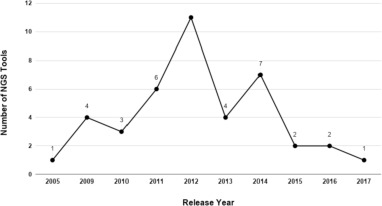

Fig. 2. Number of open-source [NGS](https://www.sciencedirect.com/topics/medicine-and-dentistry/next-generation-sequencing) tools per year.

Although most of the tools accept FASTA and FASTAQ file format as input to their tools, other tools accept other formats such as XML and SSF formats. In addition, they generate files with different formats as output files. Therefore, there is no standard input format for NGS tools which reduces the compatibility, portability, interoperability, and integration between the NGS tools, Finding 4. As a recommendation, NGS tools need to standardize the format of their input and output files.

## 6. Conclusion

In this study, we investigated the most used cloud-based Next-Generation Sequencing (NGS) data analysis and alignment tools. We studied 60 tools divided into three categories: 41 open-source NGS tools, 6 commercial NGS tools, and 13 NGS alignment tools. For these cloud-based tools, we extracted and studied crucial features that biomedical researchers and clinicians consider for selecting the appropriate NGS tools according to the needs of their works. We present many findings that provide insights and recommendations for developers of NGS tools to improve them. In the future, we are planning to conduct an empirical study to measure various Quality of Service (QoS) attributes of these tools such as their performance, efficiency, security, power consumption, and reliability.

## Data availability statement

All relevant data are within the manuscript and its Supporting Information files.

## Financial disclosure

We thank Jordan University of Science and Technology for support of this publication.

## Declaration of competing interest

No conflict of interest exists. We wish to confirm that there are no known conflicts of interest associated with this publication.

## Acknowledgements

We gratefully acknowledge Jordan University of Science and Technology for supporting this work under award number 20170030.

## References

**[1]**

K.S. Aggour, V.S. Kumar, D.P. Sangurdekar, L.A. Newberg, C.D. Kodira

**A highly parallel next-generation dna sequencing data analysis pipeline in hadoop**

Bioinformatics and biomedicine (BIBM), 2015 IEEE international conference on, IEEE (2015), pp. 756-763

[CrossRef](https://doi.org/10.1109/BIBM.2015.7359781)[View Record in Scopus](https://www.scopus.com/inward/record.url?eid=2-s2.0-84962368214&partnerID=10&rel=R3.0.0)Google Scholar

**[2]**

L. Shi, Z. Wang, W. Yu, X. Meng

**A case study of tuning mapreduce for efficient bioinformatics in the cloud**

Parallel Comput, 61 (2017), pp. 83-95

[Article](https://www.sciencedirect.com/science/article/pii/S0167819116301065)[Download PDF](https://www.sciencedirect.com/science/article/pii/S0167819116301065/pdfft?md5=28a3577dd624b565aed6bd9148069159&pid=1-s2.0-S0167819116301065-main.pdf)[View Record in Scopus](https://www.scopus.com/inward/record.url?eid=2-s2.0-85005917089&partnerID=10&rel=R3.0.0)Google Scholar

**[3]**

E.R. Mardis

**Dna sequencing technologies: 2006–2016**

Nat Protoc, 12 (2) (2017), pp. 213-218

[CrossRef](https://doi.org/10.1038/nprot.2016.182)[View Record in Scopus](https://www.scopus.com/inward/record.url?eid=2-s2.0-85010936415&partnerID=10&rel=R3.0.0)[Google Scholar](https://scholar.google.com/scholar?q=Dna%20sequencing%20technologies:%2020062016)

**[4]**

X. Guo, N. Yu, B. Li, Y. Pan

**Cloud computing for next-generation sequencing data analysis, computational methods for next generation sequencing data analysis**

(2016), pp. 1-24

[CrossRef](https://doi.org/10.1002/9781119272182.ch1)Google Scholar

**[5]**

T. Attia, M. Saeed

**Next generation sequencing technologies: a short review**

J Next Gener Sequencing Appl, 1 (2016), p. 2

[View Record in Scopus](https://www.scopus.com/inward/record.url?eid=2-s2.0-85078882723&partnerID=10&rel=R3.0.0)[Google Scholar](https://scholar.google.com/scholar_lookup?title=Next%20generation%20sequencing%20technologies%3A%20a%20short%20review&publication_year=2016&author=T.%20Attia&author=M.%20Saeed)

**[6]**

D.J. Munroe, T.J. Harris

**Third-generation sequencing fireworks at marco island**

Nat Biotechnol, 28 (5) (2010), pp. 426-428

[CrossRef](https://doi.org/10.1038/nbt0510-426)[View Record in Scopus](https://www.scopus.com/inward/record.url?eid=2-s2.0-77952157350&partnerID=10&rel=R3.0.0)[Google Scholar](https://scholar.google.com/scholar_lookup?title=Third-generation%20sequencing%20fireworks%20at%20marco%20island&publication_year=2010&author=D.J.%20Munroe&author=T.J.%20Harris)

**[7]**

C.S. Pareek, R. Smoczynski, A. Tretyn

**Sequencing technologies and genome sequencing**

J Appl Genet, 52 (4) (2011), pp. 413-435

[CrossRef](https://doi.org/10.1007/s13353-011-0057-x)[View Record in Scopus](https://www.scopus.com/inward/record.url?eid=2-s2.0-80053628299&partnerID=10&rel=R3.0.0)[Google Scholar](https://scholar.google.com/scholar_lookup?title=Sequencing%20technologies%20and%20genome%20sequencing&publication_year=2011&author=C.S.%20Pareek&author=R.%20Smoczynski&author=A.%20Tretyn)

**[8]**

I.G. Gut

**New sequencing technologies**

Clin Transl Oncol, 15 (11) (2013), pp. 879-881

[CrossRef](https://doi.org/10.1007/s12094-013-1073-6)[View Record in Scopus](https://www.scopus.com/inward/record.url?eid=2-s2.0-84886590769&partnerID=10&rel=R3.0.0)[Google Scholar](https://scholar.google.com/scholar_lookup?title=New%20sequencing%20technologies&publication_year=2013&author=I.G.%20Gut)

**[9]**

E.E. Schadt, S. Turner, A. Kasarskis

**A window into third-generation sequencing**

Hum Mol Genet, 19 (R2) (2010), pp. R227-R240

[CrossRef](https://doi.org/10.1093/hmg/ddq416)[View Record in Scopus](https://www.scopus.com/inward/record.url?eid=2-s2.0-78650868150&partnerID=10&rel=R3.0.0)[Google Scholar](https://scholar.google.com/scholar_lookup?title=A%20window%20into%20third-generation%20sequencing&publication_year=2010&author=E.E.%20Schadt&author=S.%20Turner&author=A.%20Kasarskis)

**[10]**

T.P. Niedringhaus, D. Milanova, M.B. Kerby, M.P. Snyder, A.E. Barron

**Landscape of next-generation sequencing technologies**

Anal Chem, 83 (12) (2011), pp. 4327-4341

[CrossRef](https://doi.org/10.1021/ac2010857)[View Record in Scopus](https://www.scopus.com/inward/record.url?eid=2-s2.0-79959212998&partnerID=10&rel=R3.0.0)Google Scholar

**[11]**

J.M. Heather, B. Chain

**The sequence of sequencers: the history of sequencing dna**

Genomics, 107 (1) (2016), pp. 1-8

[Article](https://www.sciencedirect.com/science/article/pii/S0888754315300410)[Download PDF](https://www.sciencedirect.com/science/article/pii/S0888754315300410/pdfft?md5=37bcddbcd9ab078e9305ac9790ab86d4&pid=1-s2.0-S0888754315300410-main.pdf)[Google Scholar](https://scholar.google.com/scholar_lookup?title=The%20sequence%20of%20sequencers%3A%20the%20history%20of%20sequencing%20dna&publication_year=2016&author=J.M.%20Heather&author=B.%20Chain)

**[12]**

A.S. Gargis, L. Kalman, D.P. Bick, C. Da Silva, D.P. Dimmock, B.H. Funke, S. Gowrisankar, M.R. Hegde, S. Kulkarni, C.E. Mason, *et al.*

**Good laboratory practice for clinical next-generation sequencing informatics pipelines**

Nat Biotechnol, 33 (7) (2015), p. 689

[CrossRef](https://doi.org/10.1038/nbt.3237)[View Record in Scopus](https://www.scopus.com/inward/record.url?eid=2-s2.0-84943587934&partnerID=10&rel=R3.0.0)Google Scholar

**[13]**

S. Goodwin, J.D. McPherson, W.R. McCombie

**Coming of age: ten years of next-generation sequencing technologies**

Nat Rev Genet, 17 (6) (2016), p. 333

[CrossRef](https://doi.org/10.1038/nrg.2016.49)[View Record in Scopus](https://www.scopus.com/inward/record.url?eid=2-s2.0-84968903135&partnerID=10&rel=R3.0.0)Google Scholar

**[14]**

J.S. Black, M. Salto-Tellez, K.I. Mills, M.A. Catherwood

**The impact of next generation sequencing technologies on haematological research–a review**

Pathogenesis, 2 (1–2) (2015), pp. 9-16

[Article](https://www.sciencedirect.com/science/article/pii/S221466361500005X)[Download PDF](https://www.sciencedirect.com/science/article/pii/S221466361500005X/pdfft?md5=44cebbdf08514a49202091913ac3abbe&pid=1-s2.0-S221466361500005X-main.pdf)[View Record in Scopus](https://www.scopus.com/inward/record.url?eid=2-s2.0-84931566186&partnerID=10&rel=R3.0.0)[Google Scholar](https://scholar.google.com/scholar?q=The%20impact%20of%20next%20generation%20sequencing%20technologies%20on%20haematological%20researcha%20review)

**[15]**

K.J. van Nimwegen, R.A. van Soest, J.A. Veltman, M.R. Nelen, G.J. van der Wilt, L.E. Vissers, J.P. Grutters

**Is the $1000 genome as near as we think? a cost analysis of next-generation sequencing**

Clin Chem, 62 (11) (2016), pp. 1458-1464

[CrossRef](https://doi.org/10.1373/clinchem.2016.258632)[View Record in Scopus](https://www.scopus.com/inward/record.url?eid=2-s2.0-84994065454&partnerID=10&rel=R3.0.0)[Google Scholar](https://scholar.google.com/scholar?q=Is%20the%201000%20genome%20as%20near%20as%20we%20think%20a%20cost%20analysis%20of%20next-generation%20sequencing)

**[16]**

A. Celesti, M. Fazio, F. Celesti, G. Sannino, S. Campo, M. Villari

**New trends in biotechnology: the point on ngs cloud computing solutions**

2016 IEEE symposium on computers and communication (ISCC), IEEE (2016), pp. 267-270

[View Record in Scopus](https://www.scopus.com/inward/record.url?eid=2-s2.0-84985906028&partnerID=10&rel=R3.0.0)Google Scholar

**[17]**

T. Kwon, W.G. Yoo, W.-J. Lee, W. Kim, D.-W. Kim

**Next-generation sequencing data analysis on cloud computing**

Genes Genomics, 37 (6) (2015), pp. 489-501

[CrossRef](https://doi.org/10.1007/s13258-015-0280-7)[View Record in Scopus](https://www.scopus.com/inward/record.url?eid=2-s2.0-84929707787&partnerID=10&rel=R3.0.0)Google Scholar

**[18]**

R.S. Thakur, R. Bandopadhyay, B. Chaudhary, S. Chatterjee

**Now and next-generation sequencing techniques: future of sequence analysis using cloud computing**

Front Genet, 3 (2012), p. 280

[View Record in Scopus](https://www.scopus.com/inward/record.url?eid=2-s2.0-84876360163&partnerID=10&rel=R3.0.0)Google Scholar

**[19]**

G. Onsongo, J. Erdmann, M.D. Spears, J. Chilton, K.B. Beckman, A. Hauge, S. Yohe, M. Schomaker, M. Bower, K.A. Silverstein, *et al.*

**Implementation of cloud based next generation sequencing data analysis in a clinical laboratory**

BMC Res Notes, 7 (1) (2014), p. 314

[View Record in Scopus](https://www.scopus.com/inward/record.url?eid=2-s2.0-84901697346&partnerID=10&rel=R3.0.0)Google Scholar

**[20]**

H. Elazhary

**Cloud computing for big data**

MAGNT Res Rep, 2 (4) (2014), pp. 135-144

[View Record in Scopus](https://www.scopus.com/inward/record.url?eid=2-s2.0-84962781750&partnerID=10&rel=R3.0.0)[Google Scholar](https://scholar.google.com/scholar_lookup?title=Cloud%20computing%20for%20big%20data&publication_year=2014&author=H.%20Elazhary)

**[21]**

Y. Jadeja, K. Modi

**Cloud computing-concepts, architecture and challenges**

2012 international conference on computing, electronics and electrical technologies (ICCEET), IEEE (2012), pp. 877-880

[CrossRef](https://doi.org/10.1109/ICCEET.2012.6203873)[Google Scholar](https://scholar.google.com/scholar_lookup?title=Cloud%20computing-concepts%2C%20architecture%20and%20challenges&publication_year=2012&author=Y.%20Jadeja&author=K.%20Modi)

**[22]**

L. Dai, X. Gao, Y. Guo, J. Xiao, Z. Zhang

**Bioinformatics clouds for big data manipulation**

Biol Direct, 7 (1) (2012), p. 43

[View Record in Scopus](https://www.scopus.com/inward/record.url?eid=2-s2.0-84870057823&partnerID=10&rel=R3.0.0)Google Scholar

**[23]**

S. Zhao, K. Watrous, C. Zhang, B. Zhang

**Cloud computing for next-generation sequencing data analysis, Cloud Computing-Architecture and Applications**

InTech, Rijeka (2017), pp. 29-51

[View Record in Scopus](https://www.scopus.com/inward/record.url?eid=2-s2.0-85060029732&partnerID=10&rel=R3.0.0)Google Scholar

**[24]**

B. Calabrese, M. Cannataro

**Bioinformatics and microarray data analysis on the cloud**

Microarray data analysis, Springer (2015), pp. 25-39

[CrossRef](https://doi.org/10.1007/7651_2015_236)[View Record in Scopus](https://www.scopus.com/inward/record.url?eid=2-s2.0-85078931048&partnerID=10&rel=R3.0.0)[Google Scholar](https://scholar.google.com/scholar_lookup?title=Bioinformatics%20and%20microarray%20data%20analysis%20on%20the%20cloud&publication_year=2015&author=B.%20Calabrese&author=M.%20Cannataro)

**[25]**

L. Qian, Z. Luo, Y. Du, L. Guo

**Cloud computing: an overview**

Springer (2009), pp. 626-631

[CrossRef](https://doi.org/10.1007/978-3-642-10665-1_63)[View Record in Scopus](https://www.scopus.com/inward/record.url?eid=2-s2.0-71749087772&partnerID=10&rel=R3.0.0)[Google Scholar](https://scholar.google.com/scholar_lookup?title=Cloud%20computing%3A%20an%20overview&publication_year=2009&author=L.%20Qian&author=Z.%20Luo&author=Y.%20Du&author=L.%20Guo)

**[26]**

Q.B. Baker, W. Al-Rashdan, Y. Jararweh

**Cloud-based tools for next-generation sequencing data analysis**

2018 fifth international conference on social networks analysis, management and security (SNAMS), IEEE (2018), pp. 99-105

[CrossRef](https://doi.org/10.1109/snams.2018.8554515)[View Record in Scopus](https://www.scopus.com/inward/record.url?eid=2-s2.0-85060050633&partnerID=10&rel=R3.0.0)[Google Scholar](https://scholar.google.com/scholar_lookup?title=Cloud-based%20tools%20for%20next-generation%20sequencing%20data%20analysis&publication_year=2018&author=Q.B.%20Baker&author=W.%20Al-Rashdan&author=Y.%20Jararweh)

**[27]**

P.L. Auer, R. Doerge

**Statistical design and analysis of rna sequencing data**

Genetics, 185 (2) (2010), pp. 405-416

[CrossRef](https://doi.org/10.1534/genetics.110.114983)[View Record in Scopus](https://www.scopus.com/inward/record.url?eid=2-s2.0-77955504378&partnerID=10&rel=R3.0.0)[Google Scholar](https://scholar.google.com/scholar_lookup?title=Statistical%20design%20and%20analysis%20of%20rna%20sequencing%20data&publication_year=2010&author=P.L.%20Auer&author=R.%20Doerge)

**[28]**

A. Barski, K. Zhao

**Genomic location analysis by chip-seq**

J Cell Biochem, 107 (1) (2009), pp. 11-18

[CrossRef](https://doi.org/10.1002/jcb.22077)[View Record in Scopus](https://www.scopus.com/inward/record.url?eid=2-s2.0-66149186985&partnerID=10&rel=R3.0.0)[Google Scholar](https://scholar.google.com/scholar_lookup?title=Genomic%20location%20analysis%20by%20chip-seq&publication_year=2009&author=A.%20Barski&author=K.%20Zhao)

**[29]**

D.A. Wheeler, M. Srinivasan, M. Egholm, Y. Shen, L. Chen, A. McGuire, W. He, Y.-J. Chen, V. Makhijani, G.T. Roth, *et al.*

**The complete genome of an individual by massively parallel dna sequencing**

Nature, 452 (7189) (2008), p. 872

[CrossRef](https://doi.org/10.1038/nature06884)[View Record in Scopus](https://www.scopus.com/inward/record.url?eid=2-s2.0-42249087308&partnerID=10&rel=R3.0.0)Google Scholar

**[30]**

J.W. Davey, P.A. Hohenlohe, P.D. Etter, J.Q. Boone, J.M. Catchen, M.L. Blaxter

**Genome-wide genetic marker discovery and genotyping using next-generation sequencing**

Nat Rev Genet, 12 (7) (2011), p. 499

[CrossRef](https://doi.org/10.1038/nrg3012)[View Record in Scopus](https://www.scopus.com/inward/record.url?eid=2-s2.0-79959435199&partnerID=10&rel=R3.0.0)Google Scholar

**[31]**

O. Harismendy, P.C. Ng, R.L. Strausberg, X. Wang, T.B. Stockwell, K.Y. Beeson, N.J. Schork, S.S. Murray, E.J. Topol, S. Levy, *et al.*

**Evaluation of next generation sequencing platforms for population targeted sequencing studies**

Genome Biol, 10 (3) (2009), p. R32

[CrossRef](https://doi.org/10.1186/gb-2009-10-3-r32)[View Record in Scopus](https://www.scopus.com/inward/record.url?eid=2-s2.0-65449144325&partnerID=10&rel=R3.0.0)Google Scholar

**[32]**

N.J. Loman, R.V. Misra, T.J. Dallman, C. Constantinidou, S.E. Gharbia, J. Wain, M.J. Pallen

**Performance comparison of benchtop high-throughput sequencing platforms**

Nat Biotechnol, 30 (5) (2012), p. 434

[CrossRef](https://doi.org/10.1038/nbt.2198)[View Record in Scopus](https://www.scopus.com/inward/record.url?eid=2-s2.0-84860756398&partnerID=10&rel=R3.0.0)Google Scholar

**[33]**

M.A. Quail, M. Smith, P. Coupland, T.D. Otto, S.R. Harris, T.R. Connor, A. Bertoni, H.P. Swerdlow, Y. Gu

**A tale of three next generation sequencing platforms: comparison of ion torrent, pacific biosciences and illumina miseq sequencers**

BMC Genomics, 13 (1) (2012), p. 341

[CrossRef](https://doi.org/10.1186/1471-2164-13-341)[View Record in Scopus](https://www.scopus.com/inward/record.url?eid=2-s2.0-84865591846&partnerID=10&rel=R3.0.0)Google Scholar

**[34]**

E.L. Van Dijk, H. Auger, Y. Jaszczyszyn, C. Thermes

**Ten years of next-generation sequencing technology**

Trends Genet, 30 (9) (2014), pp. 418-426

[Article](https://www.sciencedirect.com/science/article/pii/S0168952514001127)[Download PDF](https://www.sciencedirect.com/science/article/pii/S0168952514001127/pdfft?md5=66db4179e1da4a26dd36c0e58d0acffb&pid=1-s2.0-S0168952514001127-main.pdf)[View Record in Scopus](https://www.scopus.com/inward/record.url?eid=2-s2.0-85028165246&partnerID=10&rel=R3.0.0)Google Scholar

**[35]**

M. Escalona, S. Rocha, D. Posada

**A comparison of tools for the simulation of genomic next-generation sequencing data**

Nat Rev Genet, 17 (8) (2016), p. 459

[CrossRef](https://doi.org/10.1038/nrg.2016.57)[View Record in Scopus](https://www.scopus.com/inward/record.url?eid=2-s2.0-84975297253&partnerID=10&rel=R3.0.0)Google Scholar

**[36]**

S. Pattnaik, S. Gupta, A.A. Rao, B. Panda

**Sinc: an accurate and fast error-model based simulator for snps, indels and cnvs coupled with a read generator for short-read sequence data**

BMC Bioinf, 15 (1) (2014), p. 40

[View Record in Scopus](https://www.scopus.com/inward/record.url?eid=2-s2.0-84893173383&partnerID=10&rel=R3.0.0)Google Scholar

**[37]**

M. Kircher, S. Sawyer, M. Meyer

**Double indexing overcomes inaccuracies in multiplex sequencing on the illumina platform**

Nucleic Acids Res, 40 (1) (2011)

e3–e3

Google Scholar

**[38]**

M. Alberich, A. Artetxe, E. Santamaría-Navarro, A. Nonell-Canals, G. Maclair

**Genesis—cloud-based system for next generation sequencing analysis: a proof of concept**

Innovation in medicine and healthcare 2016, Springer (2016), pp. 291-300

[CrossRef](https://doi.org/10.1007/978-3-319-39687-3_28)[View Record in Scopus](https://www.scopus.com/inward/record.url?eid=2-s2.0-84978938047&partnerID=10&rel=R3.0.0)[Google Scholar](https://scholar.google.com/scholar?q=Genesiscloud-based%20system%20for%20next%20generation%20sequencing%20analysis:%20a%20proof%20of%20concept)

**[39]**

J.E. Stajich, D. Block, K. Boulez, S.E. Brenner, S.A. Chervitz, C. Dagdigian, G. Fuellen, J.G. Gilbert, I. Korf, H. Lapp, *et al.*

**The bioperl toolkit: perl modules for the life sciences**

Genome Res, 12 (10) (2002), pp. 1611-1618

[CrossRef](https://doi.org/10.1101/gr.361602)[View Record in Scopus](https://www.scopus.com/inward/record.url?eid=2-s2.0-18644368714&partnerID=10&rel=R3.0.0)Google Scholar

**[40]**

P. Kudtarkar, T.F. DeLuca, V.A. Fusaro, P.J. Tonellato, D.P. Wall

**Cost-effective cloud computing: a case study using the comparative genomics tool, roundup**

Evol Bioinf, 6 (2010)

EBO–S6259

Google Scholar

**[41]**

C.-L. Hung, Y.-L. Lin, G.-J. Hua, Y.-C. Hu

**Cloudtss: a tagsnp selection approach on cloud computing**

International conference on grid and distributed computing, Springer (2011), pp. 525-534

[CrossRef](https://doi.org/10.1007/978-3-642-27180-9_64)Google Scholar

**[42]**

**Ngs survey**

nov

http://tiny.cc/ngs19 (2019)

[Google Scholar](https://scholar.google.com/scholar?q=Ngs%20survey)

**[43]**

E. Afgan, D. Baker, B. Batut, M. Van Den Beek, D. Bouvier, M. Cech, J. Chilton, D. Clements, N. Coraor, B.A. Grüning, *et al.*

**The galaxy platform for accessible, reproducible and collaborative biomedical analyses: 2018 update**

Nucleic Acids Res, 46 (W1) (2018), pp. W537-W544

[CrossRef](https://doi.org/10.1093/nar/gky379)[View Record in Scopus](https://www.scopus.com/inward/record.url?eid=2-s2.0-85049781001&partnerID=10&rel=R3.0.0)Google Scholar

**[44]**

D. Blankenberg, J. Hillman-Jackson

**Analysis of next-generation sequencing data using galaxy**

Stem cell transcriptional networks, Springer (2014), pp. 21-43

[CrossRef](https://doi.org/10.1007/978-1-4939-0512-6_2)[View Record in Scopus](https://www.scopus.com/inward/record.url?eid=2-s2.0-84915780286&partnerID=10&rel=R3.0.0)[Google Scholar](https://scholar.google.com/scholar_lookup?title=Analysis%20of%20next-generation%20sequencing%20data%20using%20galaxy&publication_year=2014&author=D.%20Blankenberg&author=J.%20Hillman-Jackson)

**[45]**

M.C. Schatz

Cloudburst: highly sensitive read mapping with mapreduce, vol. 25, Oxford University Press (2009), pp. 1363-1369

[CrossRef](https://doi.org/10.1093/bioinformatics/btp236)[View Record in Scopus](https://www.scopus.com/inward/record.url?eid=2-s2.0-65649120715&partnerID=10&rel=R3.0.0)

**[46]**

B. Langmead, M.C. Schatz, J. Lin, M. Pop, S.L. Salzberg

Searching for snps with cloud computing, vol. 10, BioMed Central (2009), p. R134

[CrossRef](https://doi.org/10.1186/gb-2009-10-11-r134)[View Record in Scopus](https://www.scopus.com/inward/record.url?eid=2-s2.0-72849149423&partnerID=10&rel=R3.0.0)

**[47]**

**Basespace**

[https://developer.basespace.illumina.com/docs/content/documentation/getting-started/ overview](https://developer.basespace.illumina.com/docs/content/documentation/getting-started/%20overview), Accessed 19th Aug 2019

[Google Scholar](https://scholar.google.com/scholar?q=Basespace)

**[48]**

H. Li, R. Durbin

Fast and accurate long-read alignment with burrows–wheeler transform, vol. 26, Oxford University Press (2010), pp. 589-595

[CrossRef](https://doi.org/10.1093/bioinformatics/btp698)

**[49]**

Y. Li, S. Zhong

**Seqmapreduce: software and web service for accelerating sequence mapping, Critical Assessment of Massive Data Anaysis**

CAMDA (2009)

Google Scholar

**[50]**

A.C. Stewart, B. Osborne, T.D. Read

**Diya: a bacterial annotation pipeline for any genomics lab**

Bioinformatics, 25 (7) (2009), pp. 962-963

[CrossRef](https://doi.org/10.1093/bioinformatics/btp097)[View Record in Scopus](https://www.scopus.com/inward/record.url?eid=2-s2.0-63549147824&partnerID=10&rel=R3.0.0)[Google Scholar](https://scholar.google.com/scholar_lookup?title=Diya%3A%20a%20bacterial%20annotation%20pipeline%20for%20any%20genomics%20lab&publication_year=2009&author=A.C.%20Stewart&author=B.%20Osborne&author=T.D.%20Read)

**[51]**

A. McKenna, M. Hanna, E. Banks, A. Sivachenko, K. Cibulskis, A. Kernytsky, K. Garimella, D. Altshuler, S. Gabriel, M. Daly, *et al.*

The genome analysis toolkit: a mapreduce framework for analyzing next-generation dna sequencing data, vol. 20, Cold Spring Harbor Lab (2010), pp. 1297-1303

[CrossRef](https://doi.org/10.1101/gr.107524.110)[View Record in Scopus](https://www.scopus.com/inward/record.url?eid=2-s2.0-77956295988&partnerID=10&rel=R3.0.0)

**[52]**

M.A. DePristo, E. Banks, R. Poplin, K.V. Garimella, J.R. Maguire, C. Hartl, A.A. Philippakis, G. Del Angel, M.A. Rivas, M. Hanna, *et al.*

A framework for variation discovery and genotyping using next-generation dna sequencing data, vol. 43, Nature Research (2011), pp. 491-498

[CrossRef](https://doi.org/10.1038/ng.806)

**[53]**

**Bina careers**

http://www.bina.com/careers, Accessed 19th Aug 2019

[Google Scholar](https://scholar.google.com/scholar?q=Bina%20careers)

**[54]**

H. Li, B. Handsaker, A. Wysoker, T. Fennell, J. Ruan, N. Homer, G. Marth, G. Abecasis, R. Durbin

The sequence alignment/map format and samtools, vol. 25, Oxford University Press (2009), pp. 2078-2079

[CrossRef](https://doi.org/10.1093/bioinformatics/btp352)

**[55]**

B. Langmead, K.D. Hansen, J.T. Leek

Cloud-scale rna-sequencing differential expression analysis with myrna, vol. 11, BioMed Central (2010), p. R83

[CrossRef](https://doi.org/10.1186/gb-2010-11-8-r83)[View Record in Scopus](https://www.scopus.com/inward/record.url?eid=2-s2.0-77955343193&partnerID=10&rel=R3.0.0)

**[56]**

J. Orvis, J. Crabtree, K. Galens, A. Gussman, J.M. Inman, E. Lee, S. Nampally, D. Riley, J.P. Sundaram, V. Felix, *et al.*

Ergatis: a web interface and scalable software system for bioinformatics workflows, vol. 26, Oxford University Press (2010), pp. 1488-1492

[CrossRef](https://doi.org/10.1093/bioinformatics/btq167)[View Record in Scopus](https://www.scopus.com/inward/record.url?eid=2-s2.0-77954199176&partnerID=10&rel=R3.0.0)

**[57]**

S.V. Angiuoli, M. Matalka, A. Gussman, K. Galens, M. Vangala, D.R. Riley, C. Arze, J.R. White, O. White, W.F. Fricke

Clovr: a virtual machine for automated and portable sequence analysis from the desktop using cloud computing, vol. 12, BioMed Central (2011), p. 356

[View Record in Scopus](https://www.scopus.com/inward/record.url?eid=2-s2.0-80052121849&partnerID=10&rel=R3.0.0)

**[58]**

J.R. White, C. Arze, M. Matalka, *et al.*

**Clovr-16s: phylogenetic microbial community composition analysis based on 16s ribosomal rna amplicon sequencing–standard operating procedure, version 1.0**

Nature Publishing Group (2011)

Google Scholar

**[59]**

K. Galens, J. White, C. Arze, M. Matalka, M.G. Giglio, T.C. Team, S. Angiuoli, W.F. Fricke

**Clovr-microbe: assembly, gene finding and functional annotation of raw sequence data from single microbial genome projects–standard operating procedure, version 1.0**

Nature Publishing Group (2011)

1–1

Google Scholar

**[60]**

**Dnanexus**

https://www.dnanexus.com/contact, Accessed 19th Aug 2019

[Google Scholar](https://scholar.google.com/scholar?q=Dnanexus)

**[61]**

**Manual reference pages - maq (1)**

http://maq.sourceforge.net/maq-manpage.shtml, Accessed 19th Aug 2019

[Google Scholar](https://scholar.google.com/scholar?q=Manual%20reference%20pages%20-%20maq)

**[62]**

H. Li, J. Ruan, R. Durbin

Mapping short dna sequencing reads and calling variants using mapping quality scores, vol. 18, Cold Spring Harbor Lab (2008), pp. 1851-1858

[CrossRef](https://doi.org/10.1101/gr.078212.108)[View Record in Scopus](https://www.scopus.com/inward/record.url?eid=2-s2.0-55549097836&partnerID=10&rel=R3.0.0)

**[63]**

T. Nguyen, W. Shi, D. Ruden, Cloudaligner

A fast and full-featured mapreduce based tool for sequence mapping, vol. 4, BioMed Central (2011), p. 171

**[64]**

Y. Zhao, H. Tang, Y. Ye

Rapsearch2: a fast and memory-efficient protein similarity search tool for next-generation sequencing data, vol. 28, Oxford University Press (2011), pp. 125-126

**[65]**

**Jnomics**

https://sourceforge.net/projects/jnomics/, Accessed 19th Aug 2019

[Google Scholar](https://scholar.google.com/scholar?q=Jnomics)

**[66]**

**Jnomics—a cloud-scale sequence analysis suite**

[http://schatzlab.cshl.edu/publications/posters/2011. GenomeInformatics.Jnomics.pdf](http://schatzlab.cshl.edu/publications/posters/2011.%20GenomeInformatics.Jnomics.pdf), Accessed 19th Aug 2019

[Google Scholar](https://scholar.google.com/scholar?q=Jnomicsa%20cloud-scale%20sequence%20analysis%20suite)

**[67]**

**Thermofisher scientific**

https://www.thermofisher.com/jo/en/home.html, Accessed 19th Aug 2019

[Google Scholar](https://scholar.google.com/scholar?q=Thermofisher%20scientific)

**[68]**

M. Bhagwat, L. Young, R.R. Robison

**Using blat to find sequence similarity in closely related genomes**

Wiley Online Library (2012), pp. 10-18

Google Scholar

**[69]**

W.J. Kent

Blat—the blast-like alignment tool, vol. 12, Cold Spring Harbor Lab (2002), pp. 656-664

**[70]**

X. Feng, R. Grossman, L. Stein

Peakranger: a cloud-enabled peak caller for chip-seq data, vol. 12, BioMed Central (2011), p. 139

[CrossRef](https://doi.org/10.1002/pat.1859)

**[71]**

A. Goncalves, A. Tikhonov, A. Brazma, M. Kapushesky

A pipeline for rna-seq data processing and quality assessment, vol. 27, Oxford University Press (2011), pp. 867-869

[CrossRef](https://doi.org/10.1093/bioinformatics/btr012)[View Record in Scopus](https://www.scopus.com/inward/record.url?eid=2-s2.0-79952314593&partnerID=10&rel=R3.0.0)

**[72]**

M. Fischer, R. Snajder, S. Pabinger, A. Dander, A. Schossig, J. Zschocke, Z. Trajanoski, G. Stocker

Simplex: cloud-enabled pipeline for the comprehensive analysis of exome sequencing data, vol. 7, Public Library of Science (2012)

p. e41948

**[73]**

**Perkinelmer informatics support news**

http://www.genesifter.net/, Accessed 19th Aug 2019

[Google Scholar](https://scholar.google.com/scholar?q=Perkinelmer%20informatics%20support%20news)

**[74]**

M. Johnson, I. Zaretskaya, Y. Raytselis, Y. Merezhuk, S. McGinnis, T.L. Madden

Ncbi blast: a better web interface, vol. 36, Oxford University Press (2008), pp. W5-W9

[CrossRef](https://doi.org/10.1093/nar/gkn201)

**[75]**

T. Madden

**The blast sequence analysis tool**

The NCBI handbook (second ed.), National Center for Biotechnology Information (US) (2013)

[Internet]

[Google Scholar](https://scholar.google.com/scholar_lookup?title=The%20blast%20sequence%20analysis%20tool&publication_year=2013&author=T.%20Madden)

**[76]**

C. Camacho, G. Coulouris, V. Avagyan, N. Ma, J. Papadopoulos, K. Bealer, T.L. Madden

Blast+: architecture and applications, vol. 10, BioMed Central (2009), p. 421

**[77]**

S. Zhao, K. Prenger, L. Smith, T. Messina, H. Fan, E. Jaeger, S. Stephens

Rainbow: a tool for large-scale whole-genome sequencing data analysis using cloud computing, vol. 14, BioMed Central (2013), p. 425

[CrossRef](https://doi.org/10.1186/1471-2164-14-425)

**[78]**

D.H. Huson, N. Weber

Microbial community analysis using megan, vol. 531 (2013), pp. 465-485

[Article](https://www.sciencedirect.com/science/article/pii/B9780124078635000216)[Download PDF](https://www.sciencedirect.com/science/article/pii/B9780124078635000216/pdfft?md5=6f91121adcea02e655386667060c09bb&pid=1-s2.0-B9780124078635000216-main.pdf)[View Record in Scopus](https://www.scopus.com/inward/record.url?eid=2-s2.0-84884560630&partnerID=10&rel=R3.0.0)

**[79]**

S. Zhao, K. Prenger, L. Smith

Stormbow: a cloud-based tool for reads mapping and expression quantification in large-scale rna-seq studies, vol. 2013, Hindawi Publishing Corporation (2013), pp. 1-8

**[80]**

**Sevenbridges**

https://www.sevenbridges.com/, Accessed 19th Aug 2019

[Google Scholar](https://scholar.google.com/scholar?q=Sevenbridges)

**[81]**

C. Trapnell, M.C. Schatz

Optimizing data intensive gpgpu computations for dna sequence alignment, vol. 35, Elsevier (2009), pp. 429-440

[Article](https://www.sciencedirect.com/science/article/pii/S0167819109000714)[Download PDF](https://www.sciencedirect.com/science/article/pii/S0167819109000714/pdfft?md5=153dbdc7197aaa244c6ebc2a68d99e0e&pid=1-s2.0-S0167819109000714-main.pdf)[View Record in Scopus](https://www.scopus.com/inward/record.url?eid=2-s2.0-69949100622&partnerID=10&rel=R3.0.0)

**[82]**

H. Nordberg, K. Bhatia, K. Wang, Z. Wang

Biopig: a hadoop-based analytic toolkit for large-scale sequence data, vol. 29, Oxford University Press (2013), pp. 3014-3019

[CrossRef](https://doi.org/10.1093/bioinformatics/btt528)[View Record in Scopus](https://www.scopus.com/inward/record.url?eid=2-s2.0-84890045371&partnerID=10&rel=R3.0.0)

**[83]**

L. Jourdren, M. Bernard, M.-A. Dillies, S. Le Crom

Eoulsan: a cloud computing-based framework facilitating high throughput sequencing analyses, vol. 28, Oxford University Press (2012), pp. 1542-1543

[CrossRef](https://doi.org/10.1093/bioinformatics/bts165)[View Record in Scopus](https://www.scopus.com/inward/record.url?eid=2-s2.0-84861736018&partnerID=10&rel=R3.0.0)

**[84]**

U.S. Evani, D. Challis, J. Yu, A.R. Jackson, S. Paithankar, M.N. Bainbridge, A. Jakkamsetti, P. Pham, C. Coarfa, A. Milosavljevic, *et al.*

Atlas2 cloud: a framework for personal genome analysis in the cloud, vol. 13, BioMed Central (2012), p. S19

[CrossRef](https://doi.org/10.1186/1471-2164-13-S6-S19)

**[85]**

A.L. Delcher, S. Kasif, R.D. Fleischmann, J. Peterson, O. White, S.L. Salzberg

Alignment of whole genomes, vol. 27, Oxford University Press (1999), pp. 2369-2376

[View Record in Scopus](https://www.scopus.com/inward/record.url?eid=2-s2.0-0033153375&partnerID=10&rel=R3.0.0)

**[86]**

A.L. Delcher, A. Phillippy, J. Carlton, S.L. Salzberg

Fast algorithms for large-scale genome alignment and comparison, vol. 30, Oxford University Press (2002), pp. 2478-2483

[View Record in Scopus](https://www.scopus.com/inward/record.url?eid=2-s2.0-0036606576&partnerID=10&rel=R3.0.0)

**[87]**

A.L. Delcher, S.L. Salzberg, A.M. Phillippy

**Using mummer to identify similar regions in large sequence sets**

Wiley Online Library (2003), pp. 10-13

Google Scholar

**[88]**

S. Kurtz, A. Phillippy, A.L. Delcher, M. Smoot, M. Shumway, C. Antonescu, S.L. Salzberg

Versatile and open software for comparing large genomes, vol. 5, BioMed Central (2004), p. R12

[View Record in Scopus](https://www.scopus.com/inward/record.url?eid=2-s2.0-2942538300&partnerID=10&rel=R3.0.0)

**[89]**

Y.W. Asmann, S. Middha, A. Hossain, S. Baheti, Y. Li, H.-S. Chai, Z. Sun, P.H. Duffy, A.A. Hadad, A. Nair, *et al.*

Treat: a bioinformatics tool for variant annotations and visualizations in targeted and exome sequencing data, vol. 28, Oxford University Press (2011), pp. 277-278

**[90]**

K. Krampis, T. Booth, B. Chapman, B. Tiwari, M. Bicak, D. Field, K.E. Nelson

Cloud biolinux: pre-configured and on-demand bioinformatics computing for the genomics community, vol. 13, BioMed Central (2012), p. 42

[View Record in Scopus](https://www.scopus.com/inward/record.url?eid=2-s2.0-84858330364&partnerID=10&rel=R3.0.0)

**[91]**

H.Y. Lam, C. Pan, M.J. Clark, P. Lacroute, R. Chen, R. Haraksingh, M. O’huallachain, M.B. Gerstein, J.M. Kidd, C.D. Bustamante, *et al.*

Detecting and annotating genetic variations using the hugeseq pipeline, vol. 30, Nature Research (2012), pp. 226-229

[CrossRef](https://doi.org/10.1038/nbt.2134)[View Record in Scopus](https://www.scopus.com/inward/record.url?eid=2-s2.0-84857956783&partnerID=10&rel=R3.0.0)

**[92]**

S.M. Rumble, P. Lacroute, A.V. Dalca, M. Fiume, A. Sidow, M. Brudno

Shrimp: accurate mapping of short color-space reads, vol. 5, Public Library of Science (2009)

p. e1000386

**[93]**

M. David, M. Dzamba, D. Lister, L. Ilie, M. Brudno

Shrimp2: sensitive yet practical short read mapping, vol. 27, Oxford University Press (2011), pp. 1011-1012

[CrossRef](https://doi.org/10.1093/bioinformatics/btr046)[View Record in Scopus](https://www.scopus.com/inward/record.url?eid=2-s2.0-79953310937&partnerID=10&rel=R3.0.0)

**[94]**

L. Habegger, S. Balasubramanian, D.Z. Chen, E. Khurana, A. Sboner, A. Harmanci, J. Rozowsky, D. Clarke, M. Snyder, M. Gerstein

Vat: a computational framework to functionally annotate variants in personal genomes within a cloud-computing environment, vol. 28, Oxford University Press (2012), pp. 2267-2269

[CrossRef](https://doi.org/10.1093/bioinformatics/bts368)[View Record in Scopus](https://www.scopus.com/inward/record.url?eid=2-s2.0-84865530942&partnerID=10&rel=R3.0.0)

**[95]**

D. Hong, A. Rhie, S.-S. Park, J. Lee, Y.S. Ju, S. Kim, S.-B. Yu, T. Bleazard, H.-S. Park, H. Rhee, *et al.*

Fx: an rna-seq analysis tool on the cloud, vol. 28, Oxford University Press (2012), pp. 721-723

[CrossRef](https://doi.org/10.1093/bioinformatics/bts023)[View Record in Scopus](https://www.scopus.com/inward/record.url?eid=2-s2.0-84863289036&partnerID=10&rel=R3.0.0)

**[96]**

L. Zhang, S. Gu, Y. Liu, B. Wang, F. Azuaje

Gene set analysis in the cloud, vol. 28, Oxford University Press (2011), pp. 294-295

[View Record in Scopus](https://www.scopus.com/inward/record.url?eid=2-s2.0-85078947707&partnerID=10&rel=R3.0.0)

**[97]**

B. Langmead, C. Trapnell, M. Pop, S.L. Salzberg

Ultrafast and memory-efficient alignment of short dna sequences to the human genome, vol. 10, BioMed Central (2009), p. R25

[CrossRef](https://doi.org/10.1186/gb-2009-10-3-r25)[View Record in Scopus](https://www.scopus.com/inward/record.url?eid=2-s2.0-62349130698&partnerID=10&rel=R3.0.0)

**[98]**

E. Afgan, B. Chapman, J. Taylor

**Cloudman as a platform for tool, data, and analysis distribution**

BMC Bioinf, 13 (1) (2012), p. 315

[View Record in Scopus](https://www.scopus.com/inward/record.url?eid=2-s2.0-84869862536&partnerID=10&rel=R3.0.0)Google Scholar

**[99]**

E. Afgan, D. Baker, N. Coraor, H. Goto, I.M. Paul, K.D. Makova, A. Nekrutenko, J. Taylor

**Harnessing cloud computing with galaxy cloud**

Nat Biotechnol, 29 (11) (2011), p. 972

[CrossRef](https://doi.org/10.1038/nbt.2028)[View Record in Scopus](https://www.scopus.com/inward/record.url?eid=2-s2.0-80755125553&partnerID=10&rel=R3.0.0)Google Scholar

**[100]**

M. Niemenmaa, A. Kallio, A. Schumacher, P. Klemelä, E. Korpelainen, K. Heljanko

Hadoop-bam: directly manipulating next generation sequencing data in the cloud, vol. 28, Oxford University Press (2012), pp. 876-877

[CrossRef](https://doi.org/10.1093/bioinformatics/bts054)[View Record in Scopus](https://www.scopus.com/inward/record.url?eid=2-s2.0-84859075799&partnerID=10&rel=R3.0.0)

**[101]**

M.S. Wiewíorka, A. Messina, A. Pacholewska, S. Maffioletti, P. Gawrysiak, M.J. Okoniewski

Sparkseq: fast, scalable and cloud-ready tool for the interactive genomic data analysis with nucleotide precision, vol. 30, Oxford University Press (2014), pp. 2652-2653

[CrossRef](https://doi.org/10.1093/bioinformatics/btu343)[View Record in Scopus](https://www.scopus.com/inward/record.url?eid=2-s2.0-84907494876&partnerID=10&rel=R3.0.0)

**[102]**

B. Langmead, S.L. Salzberg

Fast gapped-read alignment with bowtie 2, vol. 9, Nature Publishing Group (2012), p. 357

[CrossRef](https://doi.org/10.1038/nmeth.1923)

**[103]**

H. Chae, S. Rhee, K.P. Nephew, S. Kim

Biovlab-mmia-ngs: microrna–mrna integrated analysis using high-throughput sequencing data, vol. 31, Oxford University Press (2014), pp. 265-267

**[104]**

**Contrail**

https://omictools.com/contrail-tool, Accessed 19th Aug 2019

[Google Scholar](https://scholar.google.com/scholar?q=Contrail)

**[105]**

J.G. Reid, A. Carroll, N. Veeraraghavan, M. Dahdouli, A. Sundquist, A. English, M. Bainbridge, S. White, W. Salerno, C. Buhay, *et al.*

Launching genomics into the cloud: deployment of mercury, a next generation sequence analysis pipeline, vol. 15, BioMed Central (2014), p. 30

[View Record in Scopus](https://www.scopus.com/inward/record.url?eid=2-s2.0-84893024407&partnerID=10&rel=R3.0.0)

**[106]**

L. Pireddu, S. Leo, G. Zanetti

Seal: a distributed short read mapping and duplicate removal tool, vol. 27, Oxford University Press (2011), pp. 2159-2160

[CrossRef](https://doi.org/10.1093/bioinformatics/btr325)[View Record in Scopus](https://www.scopus.com/inward/record.url?eid=2-s2.0-79960410567&partnerID=10&rel=R3.0.0)

**[107]**

K.J. Karczewski, G.H. Fernald, A.R. Martin, M. Snyder, N.P. Tatonetti, J.T. Dudley

Stormseq: an open-source, user- friendly pipeline for processing personal genomics data in the cloud, vol. 9, Public Library of Science (2014), p. e84860

[CrossRef](https://doi.org/10.1371/journal.pone.0084860)[View Record in Scopus](https://www.scopus.com/inward/record.url?eid=2-s2.0-84898639657&partnerID=10&rel=R3.0.0)

**[108]**

S.N. Naccache, S. Federman, N. Veeraraghavan, M. Zaharia, D. Lee, E. Samayoa, J. Bouquet, A.L. Greninger, K.-C. Luk, B. Enge, *et al.*

A cloud-compatible bioinformatics pipeline for ultrarapid pathogen identification from next-generation sequencing of clinical samples, vol. 24, Cold Spring Harbor Lab (2014), pp. 1180-1192

[CrossRef](https://doi.org/10.1101/gr.171934.113)[View Record in Scopus](https://www.scopus.com/inward/record.url?eid=2-s2.0-84904255806&partnerID=10&rel=R3.0.0)

**[109]**

A. Schumacher, L. Pireddu, M. Niemenmaa, A. Kallio, E. Korpelainen, G. Zanetti, K. Heljanko

Seqpig: simple and scalable scripting for large sequencing data sets in hadoop, vol. 30, Oxford University Press (2013), pp. 119-120

**[110]**

C. Trapnell, L. Pachter, S.L. Salzberg

Tophat: discovering splice junctions with rna-seq, vol. 25, Oxford University Press (2009), pp. 1105-1111

[CrossRef](https://doi.org/10.1093/bioinformatics/btp120)

**[111]**

D. Wang, L. Song, V. Singh, S. Rao, L. An, S. Madhavan

Snp2structure: a public and versatile resource for mapping and three-dimensional modeling of missense snps on human protein structures, vol. 13, Elsevier (2015), pp. 514-519

[Article](https://www.sciencedirect.com/science/article/pii/S2001037015000434)[Download PDF](https://www.sciencedirect.com/science/article/pii/S2001037015000434/pdfft?md5=f2616897c186e6528c9f2551c5d69fe4&pid=1-s2.0-S2001037015000434-main.pdf)[View Record in Scopus](https://www.scopus.com/inward/record.url?eid=2-s2.0-84948756375&partnerID=10&rel=R3.0.0)

**[112]**

D. Decap, J. Reumers, C. Herzeel, P. Costanza, J. Fostier

Halvade: scalable sequence analysis with mapreduce, vol. 31, Oxford University Press (2015), pp. 2482-2488

[CrossRef](https://doi.org/10.1093/bioinformatics/btv179)[View Record in Scopus](https://www.scopus.com/inward/record.url?eid=2-s2.0-84941357966&partnerID=10&rel=R3.0.0)

**[113]**

J. Oh, C.-H. Choi, M.-K. Park, B.K. Kim, K. Hwang, S.-H. Lee, S.G. Hong, A. Nasir, W.-S. Cho, K.M. Kim

Clustom-cloud: in-memory data grid-based software for clustering 16s rrna sequence data in the cloud environment, vol. 11, Public Library of Science (2016)

e0151064

**[114]**

D. Kim, B. Langmead, S.L. Salzberg

Hisat: a fast spliced aligner with low memory requirements, vol. 12, Nature Publishing Group (2015), p. 357

[View Record in Scopus](https://www.scopus.com/inward/record.url?eid=2-s2.0-84926519013&partnerID=10&rel=R3.0.0)

**[115]**

W. Tang, J. Bischof, N. Desai, K. Mahadik, W. Gerlach, T. Harrison, A. Wilke, F. Meyer

**Workload characterization for mg-rast metagenomic data analytics service in the cloud**

Big data (big data), 2014 IEEE international conference on, IEEE (2014), pp. 56-63

[CrossRef](https://doi.org/10.1109/BigData.2014.7004394)Google Scholar

**[116]**

A. Wilke, W. Gerlach, T. Harrison, T. Paczian, W.L. Trimble, F. Meyer

Mg-rast manual for version 4, vol. 3 (2017)

revision

**[117]**

H. Elshazly, Y. Souilmi, P.J. Tonellato, D.P. Wall, M. Abouelhoda

Mc-genomekey: a multicloud system for the detection and annotation of genomic variants, vol. 18, BioMed Central (2017), p. 49

[View Record in Scopus](https://www.scopus.com/inward/record.url?eid=2-s2.0-85011043657&partnerID=10&rel=R3.0.0)

**[118]**

H. Perrin, M. Denorme, J. Grosjean, E. Dynomant, V.J. Henry, F. Pichon, S. Darmoni, A. Desfeux, B.J. Gonzalez, *et al.*

**Omictools: a community-driven search engine for biological data analysis**

(2017)

Google Scholar

## Cited by (4)

### q-frame hash comparison based exact string matching algorithms for DNA sequences

- 2022, Concurrency and Computation: Practice and Experience

### easyfm: An easy software suite for file manipulation of Next Generation Sequencing data on desktops

- 2021, bioRxiv

### Cloud Computing Enabled Big Multi-Omics Data Analytics

- 2021, Bioinformatics and Biology Insights

### Next Generation Sequencing and Bioinformatics Analysis of Family Genetic Inheritance

- 2020, Frontiers in Genetics

© 2020 The Authors. Published by Elsevier Ltd.

Citations

Captures

Social Media

[figure not shown]

[figure not shown]